# RelatorioExp

2024-12-16

# 1 Preparo dos dados

## 1.1 Versão do banco

Relatório mais recente: “2024-12-16”

**Versão da planilha deleg**: 2023-12-20

**Versão da planilha orgs**: 2023-12-20

**Versão da planilha class**: 2022-06-29

**Versão da planilha eventos**: 2023-12-14

**Versão da planilha individuos**: 2023-12-21

# 2 Dados experiência

## 2.1 Tamanho da rede quando se considera recorrência

Qual o n de orgs qdo se filtra n participações (1, 2, 3, etc)? Em tabela, quebrar essas organizações por tipo org. Em tabela, ver a recorrência em clima / ‘gdes conf’ vs demais / ‘temas menores’

Para isso, modelamos os dados como uma rede dinâmica que indivíduos como nós (projetada a partir da rede bipartite indivíduo-evento). Esse formato dá maior liberdade para a análise, viabilizando filtros por anos, temas, etc ao mesmo tempo que podemos acessar dados por organização (colapsando os nós de indivíduos de modo a agrupá-los por org).

Primeiro vamos ver como muda o tamanho da rede no nível dos indivíduos quando filtramos pelo número de eventos frequentados. Para a rede estática completa, bastaria observar a variável do n de participações. Se queremos filtrar, é preciso pensar outras estratégias (ou refazer a rede a cada filtro).

Dados de interesse:

- % das organizações a cada ano que foi na anterior;
- % das organizações no ano que nunca participou antes;
- (idem com indivíduos)

Anotações sobre como implementar:

p/ pegar se foi na anterior, posso pegar nodelist da rede dinâmica, que tem o id do indivíduo/org e os anos em que participou (cada um em um row). p/ cada row, posso criar duas colunas - é a primeira participação? qual a part anterior/participou do evento anterior? com esses dados, agrupa por evento (pra pegar a delegação toda) e, se for o caso, org. p/ cada, summarize com % de entrantes etc.

## 2.2 Entrantes e recorrentes nos eventos

Quantos indivíduos participam em mais de N eventos?

Number of individuals in network with more than N participations

| N | count_total |
| --- | --- |
| 0 | 4806 |
| 1 | 1208 |
| 2 | 581 |
| 3 | 372 |
| 4 | 252 |
| 5 | 185 |
| 6 | 136 |
| 7 | 90 |
| 8 | 64 |
| 9 | 55 |
| 10 | 41 |

Quantas organizações participam em mais de N eventos?

Number of orgs in network with more than N participations

| N | count_total | count_soccivil | count_empres | count_govfed |
| --- | --- | --- | --- | --- |
| 0 | 747 | 174 | 146 | 176 |
| 1 | 417 | 66 | 85 | 133 |
| 2 | 276 | 42 | 55 | 89 |
| 3 | 230 | 30 | 42 | 77 |
| 4 | 209 | 26 | 37 | 74 |
| 5 | 176 | 21 | 27 | 66 |
| 10 | 108 | 14 | 12 | 44 |
| 15 | 76 | 6 | 8 | 29 |
| 20 | 58 | 3 | 5 | 23 |

Quantos indivíduos participam de eventos a cada ano?

Number of individual participants per year

| ano_part | count_indparticipants |
| --- | --- |
| 1961 | 2 |
| 1962 | 5 |
| 1964 | 2 |
| 1965 | 1 |
| 1967 | 3 |
| 1969 | 12 |
| 1970 | 6 |
| 1972 | 32 |
| 1973 | 16 |
| 1974 | 4 |
| 1975 | 9 |
| 1976 | 1 |
| 1977 | 4 |
| 1978 | 9 |
| 1979 | 13 |
| 1980 | 10 |
| 1981 | 2 |
| 1982 | 10 |
| 1983 | 3 |
| 1984 | 3 |
| 1985 | 11 |
| 1986 | 4 |
| 1987 | 14 |
| 1988 | 7 |
| 1989 | 12 |
| 1990 | 26 |
| 1991 | 65 |
| 1992 | 200 |
| 1993 | 31 |
| 1994 | 53 |
| 1995 | 50 |
| 1996 | 60 |
| 1997 | 33 |
| 1998 | 75 |
| 1999 | 116 |
| 2000 | 121 |
| 2001 | 117 |
| 2002 | 388 |
| 2003 | 88 |
| 2004 | 270 |
| 2005 | 192 |
| 2006 | 269 |
| 2007 | 258 |
| 2008 | 297 |
| 2009 | 638 |
| 2010 | 635 |
| 2011 | 300 |
| 2012 | 1666 |
| 2013 | 231 |
| 2014 | 389 |
| 2015 | 283 |
| 2016 | 258 |
| 2017 | 212 |
| 2018 | 218 |
| 2019 | 223 |
| 2020 | 5 |
| 2021 | 14 |

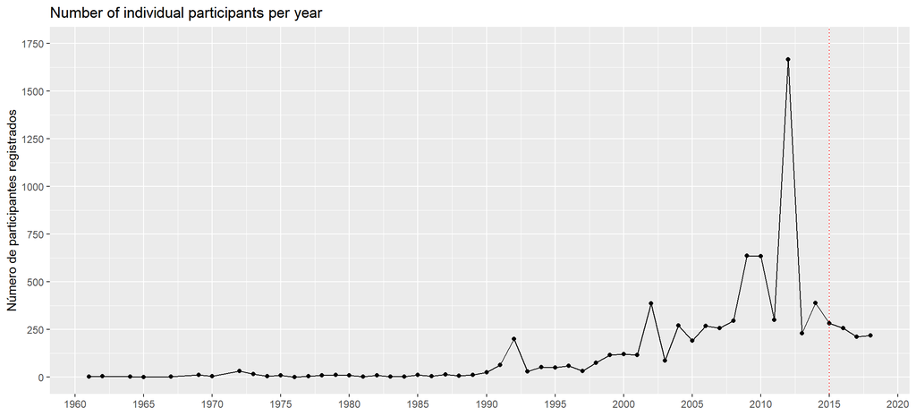

A variação ano-a-ano pode ser uma medida problemática, porque os eventos têm periodicidade variável (e.g., COP UNFCCC é anual, mas CBD é bianual). Mas olhando o gráfico, acho que a tendência geral segue visível.

### 2.2.1 número de participantes recorrentes

A participação em um único evento, pode ser um critério um pouco amplo demais para avaliar o tamanho de uma comunidade de políticas. É preciso que a participação seja recorrente. No início do relatório, fazemos esse mapeamento para a rede estática, mas queremos agora ver como isso muda ao longo do tempo.

Para avaliar o número de participantes recorrentes, é importante a) levar em consideração um período temporal mais amplo (dificilmente há oportunidade de vários eventos no mesmo ano) e b) definir um n mínimo de eventos para os participantes.

1. Participantes recorrentes em um mesmo mandato presidencial

Número de participantes recorrentes por período

| mandato | ind_1plus | ind_2plus | ind_3plus | ind_4plus | ind_5plus |
| --- | --- | --- | --- | --- | --- |
| Ditadura | 95 | 20 | 5 | 2 | 0 |
| Sarney | 39 | 7 | 2 | 0 | 0 |
| Collor-Itamar | 257 | 48 | 19 | 11 | 9 |
| FHC1 | 139 | 41 | 15 | 12 | 7 |
| FHC2 | 529 | 113 | 46 | 27 | 15 |
| Lula1 | 548 | 161 | 66 | 29 | 10 |
| Lula2 | 1366 | 293 | 105 | 43 | 15 |
| Dilma1 | 2112 | 268 | 115 | 60 | 15 |
| Dilma2Temer | 711 | 168 | 54 | 25 | 8 |

Para aprofundar um pouco a análise, vale observar quem são os participantes recorrentes nesses variados períodos. Os indivíduos mais experientes em cada tema são descritos mais abaixo, mas é útil trazer aqui os indivíduos recorrentes nos períodos com uma comunidade pouco estabelecida (ditadura e sarney) para ver se há algum padrão.

Indivíduos com 3+ participações na ditadura

| mandato | id_individuo | count | nome_padrao |
| --- | --- | --- | --- |
| Ditadura | 402 | 4 | Mauro Silva Reis |
| Ditadura | 403 | 3 | Bernardo de Azevedo Brito |
| Ditadura | 469 | 4 | Luiz Filipe de Macedo Soares Guimarães |
| Ditadura | 4732 | 3 | Orlando Augusto Amaral Affonso |
| Ditadura | 4735 | 3 | Hugo Bernardi Jr |

Indivíduos com 2+ participações em Sarney

| mandato | id_individuo | count | nome_padrao |
| --- | --- | --- | --- |
| Sarney | 1 | 3 | Júlio Glinternick Bitelli |
| Sarney | 7 | 2 | Almir Franco de Sá Barbuda |
| Sarney | 335 | 2 | Lúcia Helena de Oliveira |
| Sarney | 415 | 2 | Igor Kipman |
| Sarney | 2135 | 3 | Sergio Augusto de Abreu e Lima Florencio |
| Sarney | 2138 | 2 | Caio Marcio Ranieri Colombo |
| Sarney | 4749 | 2 | Luiz Carlos Ferreira da Silva |

2. Número de participantes recorrentes em janelas de 3 anos

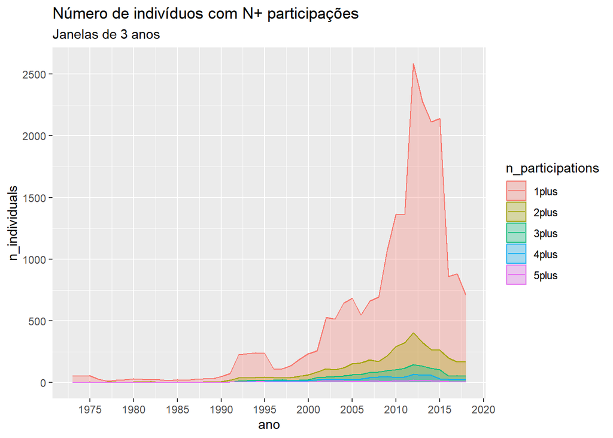

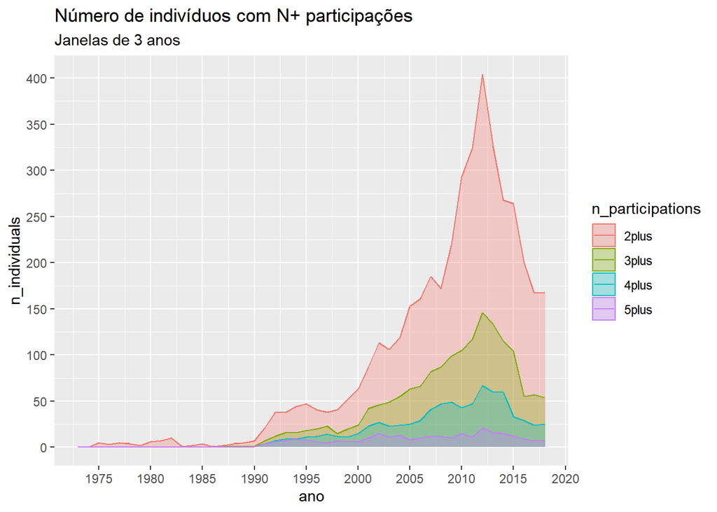

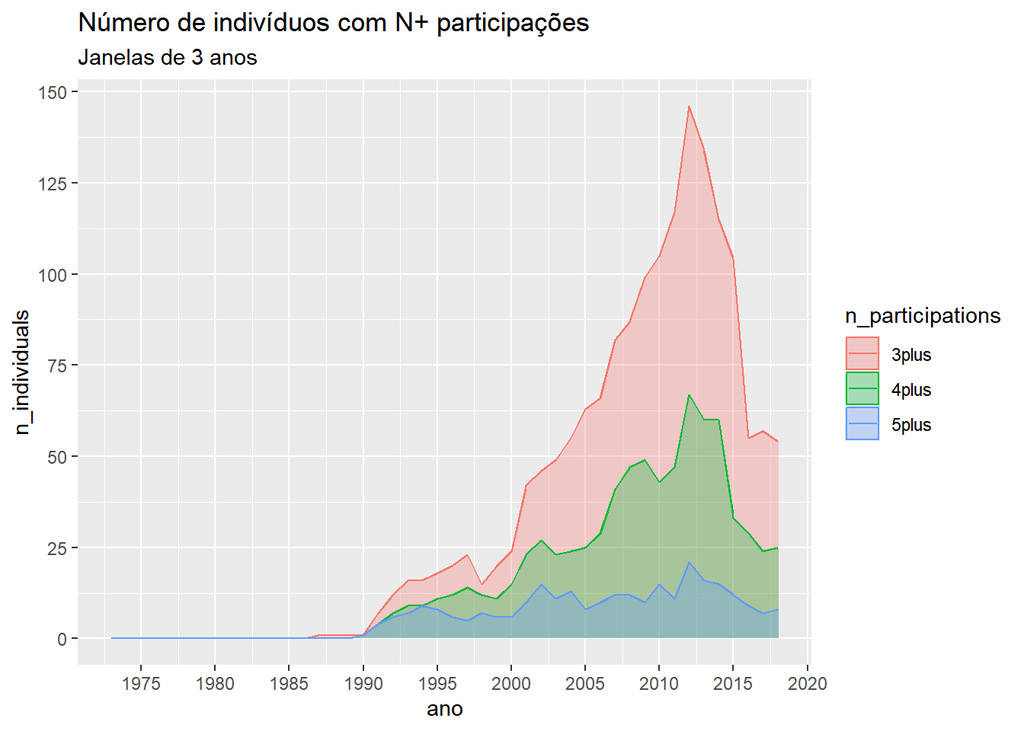

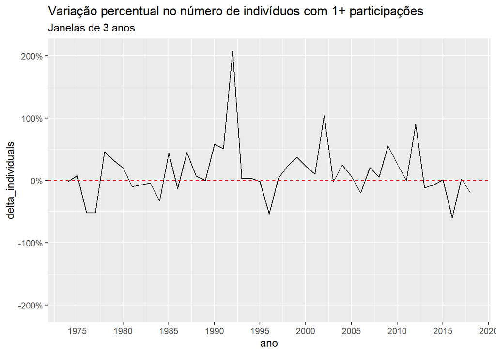

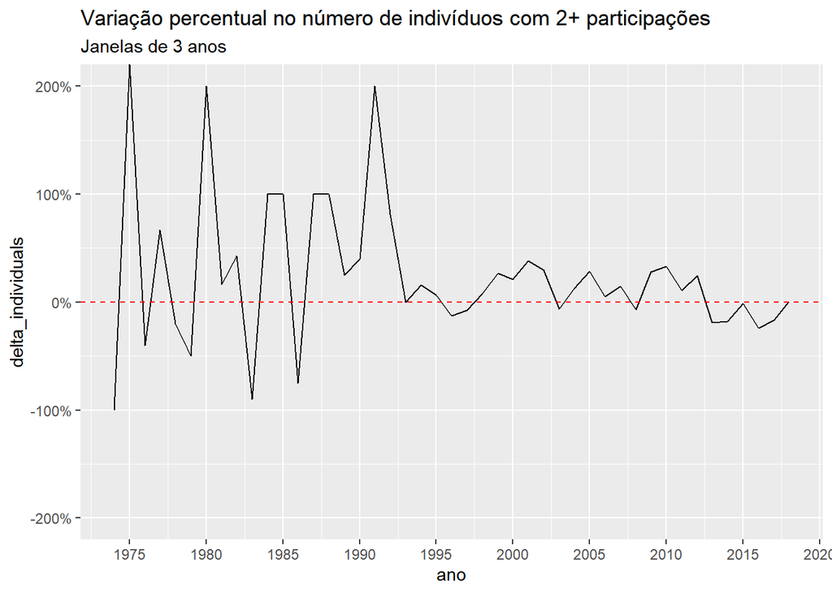

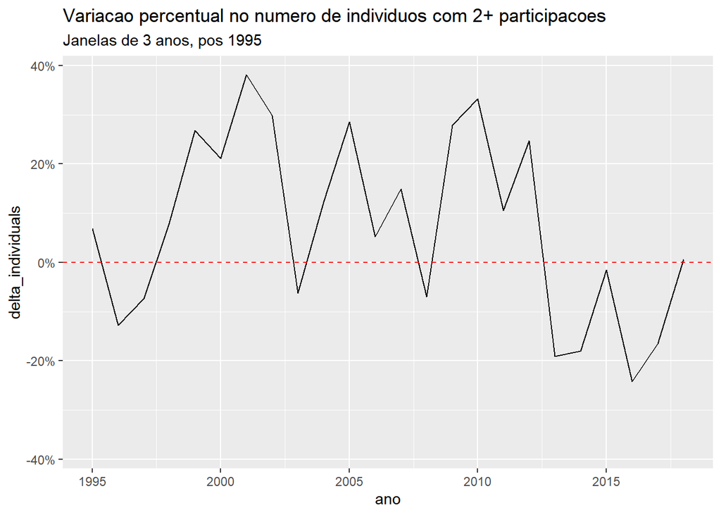

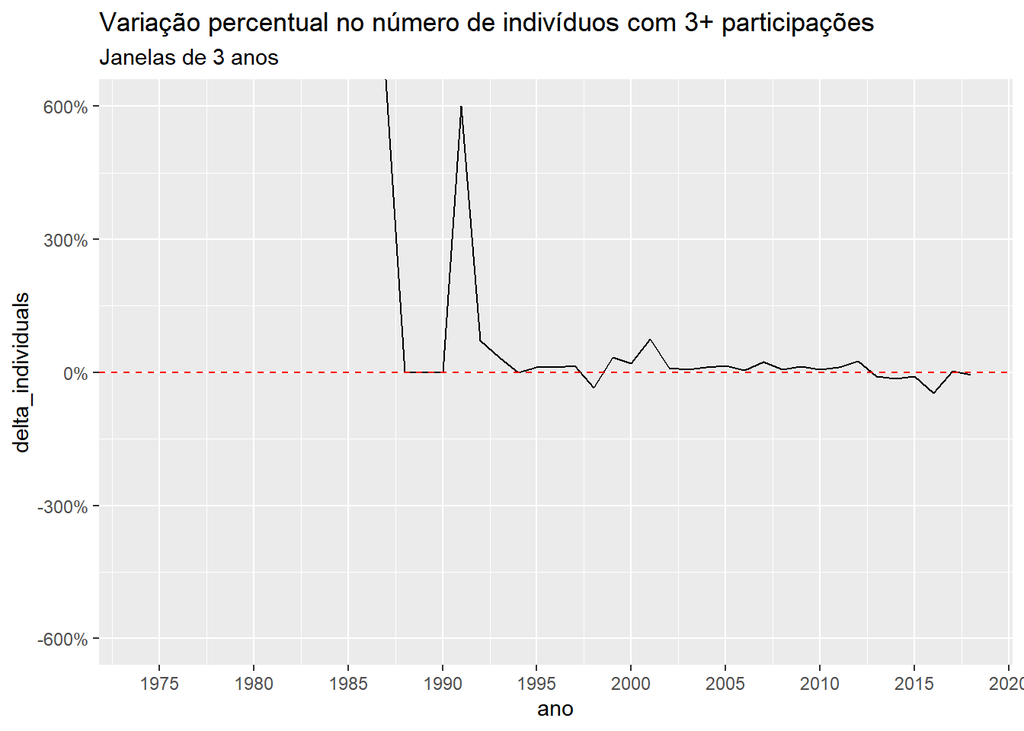

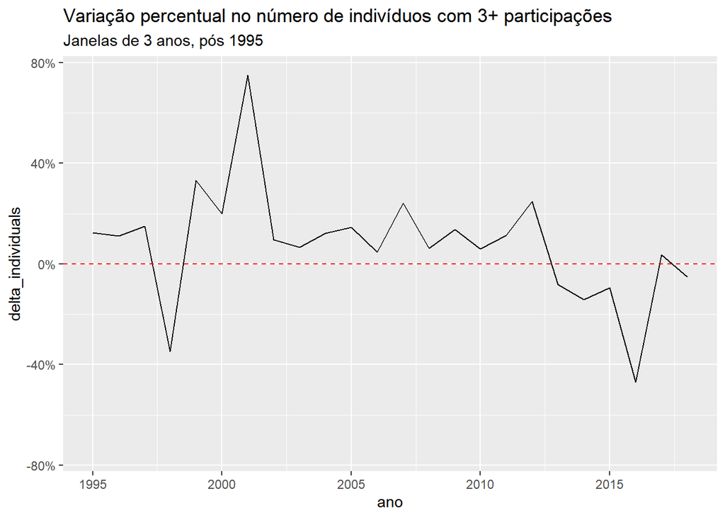

Número de indivíduos com N+ participações em janelas de 3 anos

| ano | ind_1plus | ind_2plus | ind_3plus | ind_4plus | ind_5plus |
| --- | --- | --- | --- | --- | --- |
| 1973 | 53 | 1 | 0 | 0 | 0 |
| 1974 | 52 | 0 | 0 | 0 | 0 |
| 1975 | 56 | 5 | 0 | 0 | 0 |
| 1976 | 27 | 3 | 0 | 0 | 0 |
| 1977 | 13 | 5 | 0 | 0 | 0 |
| 1978 | 19 | 4 | 0 | 0 | 0 |
| 1979 | 25 | 2 | 0 | 0 | 0 |
| 1980 | 30 | 6 | 0 | 0 | 0 |
| 1981 | 27 | 7 | 0 | 0 | 0 |
| 1982 | 25 | 10 | 0 | 0 | 0 |
| 1983 | 24 | 1 | 0 | 0 | 0 |
| 1984 | 16 | 2 | 0 | 0 | 0 |
| 1985 | 23 | 4 | 0 | 0 | 0 |
| 1986 | 20 | 1 | 0 | 0 | 0 |
| 1987 | 29 | 2 | 1 | 0 | 0 |
| 1988 | 31 | 4 | 1 | 0 | 0 |
| 1989 | 31 | 5 | 1 | 0 | 0 |
| 1990 | 49 | 7 | 1 | 1 | 1 |
| 1991 | 74 | 21 | 7 | 4 | 4 |
| 1992 | 227 | 38 | 12 | 7 | 6 |
| 1993 | 234 | 38 | 16 | 9 | 7 |
| 1994 | 242 | 44 | 16 | 9 | 9 |
| 1995 | 237 | 47 | 18 | 11 | 8 |
| 1996 | 109 | 41 | 20 | 12 | 6 |
| 1997 | 113 | 38 | 23 | 14 | 5 |
| 1998 | 139 | 41 | 15 | 12 | 7 |
| 1999 | 191 | 52 | 20 | 11 | 6 |
| 2000 | 235 | 63 | 24 | 15 | 6 |
| 2001 | 259 | 87 | 42 | 23 | 10 |
| 2002 | 529 | 113 | 46 | 27 | 15 |
| 2003 | 515 | 106 | 49 | 23 | 11 |
| 2004 | 644 | 119 | 55 | 24 | 13 |
| 2005 | 684 | 153 | 63 | 25 | 8 |
| 2006 | 548 | 161 | 66 | 29 | 10 |
| 2007 | 660 | 185 | 82 | 41 | 12 |
| 2008 | 694 | 172 | 87 | 47 | 12 |
| 2009 | 1081 | 220 | 99 | 49 | 10 |
| 2010 | 1366 | 293 | 105 | 43 | 15 |
| 2011 | 1362 | 324 | 117 | 47 | 11 |
| 2012 | 2584 | 404 | 146 | 67 | 21 |
| 2013 | 2277 | 327 | 134 | 60 | 16 |
| 2014 | 2112 | 268 | 115 | 60 | 15 |
| 2015 | 2141 | 264 | 104 | 33 | 12 |
| 2016 | 861 | 200 | 55 | 29 | 9 |
| 2017 | 882 | 167 | 57 | 24 | 7 |
| 2018 | 711 | 168 | 54 | 25 | 8 |

## 2.3 Experiência ao longo do tempo

- P/ orgs específicas (MRE, MMA, MCT), experiencia média a cada ano.
- Filtro por tema (só clima, ‘gdes temas’, etc)
- Tabela com top X indivíduos mais experientes. Contar experiência em anos com participação ou em n de reuniões.
- Tabela geral e separada em diferentes periodizações.

### 2.3.1 Quem são os indivíduos mais experientes?

Estou usando o critério de experiência como o número de eventos prévios. Assim, a experiência absoluta consiste no número de eventos nos quais o indivíduo (ou a organização) estiveram presentes; a experiência contínua leva em conta o número de eventos em sequência com presença do indivíduo (ou organização), isto é, zera quando há uma interrupção da presença. Nas tabelas, ordeno os dados por experiência absoluta. nota: título das tabelas traz as datas usadas como limite na função - o fato de apresentar algo como 1970 até 2018 não significa que há participações desde 1970 (CBD, no caso, inicia em 1988 e unfccc em 1991)

20 indivíduos mais experientes na CBD (1970 até 2018)

| nome_padrao | conf | ano | abs | cont |
| --- | --- | --- | --- | --- |
| Braulio Ferreira de Souza Dias | CBD, COP14 | 2018 | 9 | 0 |
| Lidio Coradin | CBD, COP14 | 2018 | 8 | 0 |
| Ana Paula Leite Prates | CBD, COP14 | 2018 | 7 | 1 |
| Maria José Amstalden Sampaio | CBD, COP14 | 2018 | 5 | 0 |
| Joaquim Aparecido Machado | CBD, COP14 | 2018 | 5 | 0 |
| Márcio Antônio Teixeira Mazzaro | CBD, COP14 | 2018 | 5 | 2 |
| Henry Philippe Ibáñez de Novion | CBD, COP14 | 2018 | 5 | 4 |
| Eliana Maria Gouveia Fontes | CBD, COP14 | 2018 | 4 | 0 |
| Rosa Miriam de Vasconcelos | CBD, COP14 | 2018 | 4 | 0 |
| Mitzi Gurgel Valente da Costa | CBD, COP14 | 2018 | 4 | 1 |
| Fernando Antônio Lyrio Silva | CBD, COP14 | 2018 | 4 | 0 |
| Maria Iolita Bampi | CBD, COP14 | 2018 | 4 | 0 |
| Ana Carolina Albero Belisário | CBD, COP14 | 2018 | 4 | 0 |
| Marco Antonio Ramos Caminha | CBD, COP14 | 2018 | 4 | 2 |
| Fernando Estellita Lins de Salvo Coimbra | CBD, COP14 | 2018 | 4 | 3 |
| Elisa Romano Dezolt | CBD, COP14 | 2018 | 4 | 1 |
| Rodrigo Carvalho de Abreu Lima | CBD, COP14 | 2018 | 4 | 2 |
| Rosa Maria Lemos de Sá | CBD, COP14 | 2018 | 4 | 2 |
| Marciano Toledo da Silva | CBD, COP14 | 2018 | 4 | 2 |
| Vanderlei Perez Canhos | CBD, COP14 | 2018 | 3 | 0 |

20 indivíduos mais experientes na UNFCCC (1970 até 2018)

| nome_padrao | conf | ano | abs | cont |
| --- | --- | --- | --- | --- |
| Luiz Gylvan Meira Filho | UNFCCC, COP24 | 2018 | 28 | 0 |
| José Domingos Gonzales Miguez | UNFCCC, COP24 | 2018 | 25 | 24 |
| Haroldo de Oliveira Machado Filho | UNFCCC, COP24 | 2018 | 20 | 15 |
| Thelma Krug | UNFCCC, COP24 | 2018 | 17 | 0 |
| Marcelo Theoto Rocha | UNFCCC, COP24 | 2018 | 17 | 16 |
| Fabio José Feldmann | UNFCCC, COP24 | 2018 | 16 | 0 |
| Newton Paciornik | UNFCCC, COP24 | 2018 | 15 | 0 |
| Luiz Pinguelli Rosa | UNFCCC, COP24 | 2018 | 15 | 0 |
| Adriano Santhiago de Oliveira | UNFCCC, COP24 | 2018 | 15 | 13 |
| Maria de Fátima Sales Abreu Passos | UNFCCC, COP24 | 2018 | 14 | 0 |
| Branca Bastos Americano | UNFCCC, COP24 | 2018 | 14 | 0 |
| Rubens Harry Born | UNFCCC, COP24 | 2018 | 12 | 0 |
| Suzana Kahn Ribeiro | UNFCCC, COP24 | 2018 | 12 | 0 |
| Marina Freitas Gonçalves de Araújo Grossi | UNFCCC, COP24 | 2018 | 12 | 0 |
| Thiago de Araújo Mendes | UNFCCC, COP24 | 2018 | 12 | 12 |
| Everton Vieira Vargas | UNFCCC, COP24 | 2018 | 11 | 0 |
| Laura Maria Regina Tetti | UNFCCC, COP24 | 2018 | 11 | 0 |
| Luiz Alberto Figueiredo Machado | UNFCCC, COP24 | 2018 | 11 | 0 |
| Neilton Fidélis da Silva | UNFCCC, COP24 | 2018 | 11 | 0 |
| Paula Pinto Bennati | UNFCCC, COP24 | 2018 | 10 | 0 |

Para uma análise mais profunda, vale incluir um corte mais específico, que permita ver se o perfil dos mais experientes muda ao longo do tempo. Abaixo, apresentamos as tabelas para clima com cortes temporais. Para as tabelas, conta apenas a experiência adquirida dentro do período marcado.

10 indivíduos mais experientes na UNFCCC (1990 até 1995)

| nome_padrao | conf | ano | abs | cont |
| --- | --- | --- | --- | --- |
| Luiz Gylvan Meira Filho | UNFCCC, INC11 | 1995 | 10 | 8 |
| Luiz Gylvan Meira Filho | UNFCCC, COP01 | 1995 | 10 | 0 |
| Pedro Motta Pinto Coelho | UNFCCC, INC11 | 1995 | 7 | 0 |
| Pedro Motta Pinto Coelho | UNFCCC, COP01 | 1995 | 7 | 0 |
| Hadil Fontes da Rocha Vianna | UNFCCC, INC11 | 1995 | 6 | 0 |
| Hadil Fontes da Rocha Vianna | UNFCCC, COP01 | 1995 | 6 | 0 |
| Luiz Filipe de Macedo Soares Guimarães | UNFCCC, INC11 | 1995 | 4 | 0 |
| Luiz Filipe de Macedo Soares Guimarães | UNFCCC, COP01 | 1995 | 4 | 0 |
| Everton Vieira Vargas | UNFCCC, INC11 | 1995 | 4 | 0 |
| Everton Vieira Vargas | UNFCCC, COP01 | 1995 | 4 | 0 |

5 organizações mais experientes na UNFCCC (1990 até 1995)

| org_limpo | conf | ano | abs | cont |
| --- | --- | --- | --- | --- |
| Ministério das Relações Exteriores | UNFCCC, INC11 | 1995 | 11 | 11 |
| Ministério das Relações Exteriores | UNFCCC, COP01 | 1995 | 11 | 0 |
| Secretaria de Ciência e Tecnologia da Presidência | UNFCCC, INC11 | 1995 | 6 | 0 |
| Secretaria de Ciência e Tecnologia da Presidência | UNFCCC, COP01 | 1995 | 6 | 0 |
| INPE - Instituto Nacional de Pesquisas Espaciais | UNFCCC, INC11 | 1995 | 5 | 1 |

10 indivíduos mais experientes na UNFCCC (1996 até 2002)

| nome_padrao | conf | ano | abs | cont |
| --- | --- | --- | --- | --- |
| Luiz Gylvan Meira Filho | UNFCCC, COP08 | 2002 | 7 | 7 |
| José Domingos Gonzales Miguez | UNFCCC, COP08 | 2002 | 7 | 7 |
| Fabio José Feldmann | UNFCCC, COP08 | 2002 | 6 | 6 |
| Newton Paciornik | UNFCCC, COP08 | 2002 | 6 | 6 |
| Rubens Harry Born | UNFCCC, COP08 | 2002 | 5 | 0 |
| Haroldo de Oliveira Machado Filho | UNFCCC, COP08 | 2002 | 5 | 5 |
| Laura Maria Regina Tetti | UNFCCC, COP08 | 2002 | 5 | 5 |
| Demetrio Bueno Carvalho | UNFCCC, COP08 | 2002 | 4 | 0 |
| Heloiso Bueno Figueiredo | UNFCCC, COP08 | 2002 | 4 | 0 |
| Flávio Celio Goldman | UNFCCC, COP08 | 2002 | 4 | 0 |

5 organizações mais experientes na UNFCCC (1996 até 2002)

| org_limpo | conf | ano | abs | cont |
| --- | --- | --- | --- | --- |
| Ministério da Ciência e Tecnologia | UNFCCC, COP08 | 2002 | 7 | 7 |
| Ministério das Relações Exteriores | UNFCCC, COP08 | 2002 | 7 | 7 |
| Ministério do Meio Ambiente | UNFCCC, COP08 | 2002 | 7 | 7 |
| AEB - Agência Espacial Brasileira | UNFCCC, COP08 | 2002 | 6 | 0 |
| Vitae Civilis | UNFCCC, COP08 | 2002 | 5 | 0 |

10 indivíduos mais experientes na UNFCCC (2003 até 2010)

| nome_padrao | conf | ano | abs | cont |
| --- | --- | --- | --- | --- |
| Marcelo Theoto Rocha | UNFCCC, COP16 | 2010 | 7 | 7 |
| Luiz Pinguelli Rosa | UNFCCC, COP16 | 2010 | 7 | 7 |
| José Domingos Gonzales Miguez | UNFCCC, COP16 | 2010 | 7 | 7 |
| Fernando Antônio Lyrio Silva | UNFCCC, COP16 | 2010 | 7 | 7 |
| Fabio José Feldmann | UNFCCC, COP16 | 2010 | 7 | 7 |
| Thelma Krug | UNFCCC, COP16 | 2010 | 7 | 7 |
| Branca Bastos Americano | UNFCCC, COP16 | 2010 | 7 | 7 |
| Haroldo de Oliveira Machado Filho | UNFCCC, COP16 | 2010 | 7 | 7 |
| Hércules Ribeiro Martins | UNFCCC, COP16 | 2010 | 7 | 7 |
| Maria de Fátima Sales Abreu Passos | UNFCCC, COP16 | 2010 | 7 | 7 |

5 organizações mais experientes na UNFCCC (2003 até 2010)

| org_limpo | conf | ano | abs | cont |
| --- | --- | --- | --- | --- |
| Ministério do Meio Ambiente | UNFCCC, COP16 | 2010 | 7 | 7 |
| Ministério das Relações Exteriores | UNFCCC, COP16 | 2010 | 7 | 7 |
| Ministério de Minas e Energia | UNFCCC, COP16 | 2010 | 7 | 7 |
| CEBDS - Conselho Empresarial Brasileiro para o Desenvolvimento Sustentável | UNFCCC, COP16 | 2010 | 7 | 7 |
| Universidade Federal do Rio de Janeiro | UNFCCC, COP16 | 2010 | 7 | 7 |

10 indivíduos mais experientes na UNFCCC (2011 até 2018)

| nome_padrao | conf | ano | abs | cont |
| --- | --- | --- | --- | --- |
| José Domingos Gonzales Miguez | UNFCCC, COP24 | 2018 | 7 | 7 |
| Thiago de Araújo Mendes | UNFCCC, COP24 | 2018 | 7 | 7 |
| Marcelo Theoto Rocha | UNFCCC, COP24 | 2018 | 7 | 7 |
| Fernando Estellita Lins de Salvo Coimbra | UNFCCC, COP24 | 2018 | 7 | 7 |
| Adriano Santhiago de Oliveira | UNFCCC, COP24 | 2018 | 7 | 7 |
| Haroldo de Oliveira Machado Filho | UNFCCC, COP24 | 2018 | 7 | 7 |
| Túlio César Mourthé de Alvim Andrade | UNFCCC, COP24 | 2018 | 6 | 3 |
| Gustavo Barbosa Mozzer | UNFCCC, COP24 | 2018 | 6 | 4 |
| Izabella Mônica Vieira Teixeira | UNFCCC, COP24 | 2018 | 5 | 0 |
| Luciana Abade Silveira | UNFCCC, COP24 | 2018 | 5 | 0 |

5 organizações mais experientes na UNFCCC (2011 até 2018)

| org_limpo | conf | ano | abs | cont |
| --- | --- | --- | --- | --- |
| Ministério do Meio Ambiente | UNFCCC, COP24 | 2018 | 7 | 7 |
| Ministério das Relações Exteriores | UNFCCC, COP24 | 2018 | 7 | 7 |
| Sem informação | UNFCCC, COP24 | 2018 | 7 | 7 |
| Ministério da Ciência e Tecnologia | UNFCCC, COP24 | 2018 | 7 | 7 |
| EMBRAPA - Empresa Brasileira de Pesquisa Agropecuária | UNFCCC, COP24 | 2018 | 7 | 7 |

### 2.3.2 Como varia a experiência das organizações no tempo?

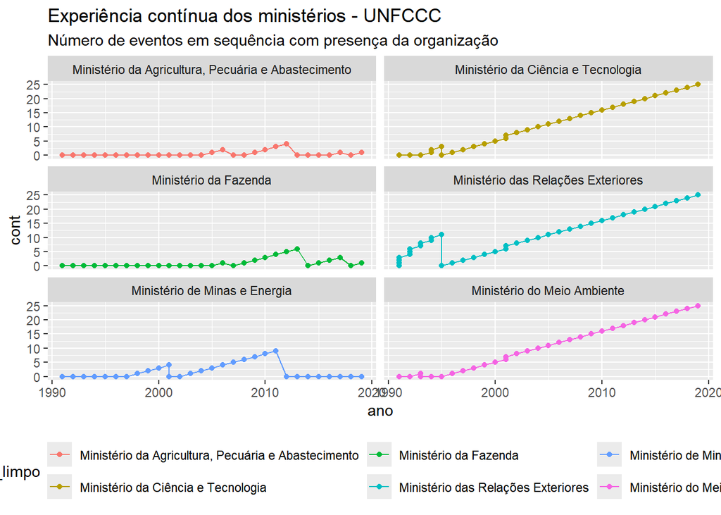

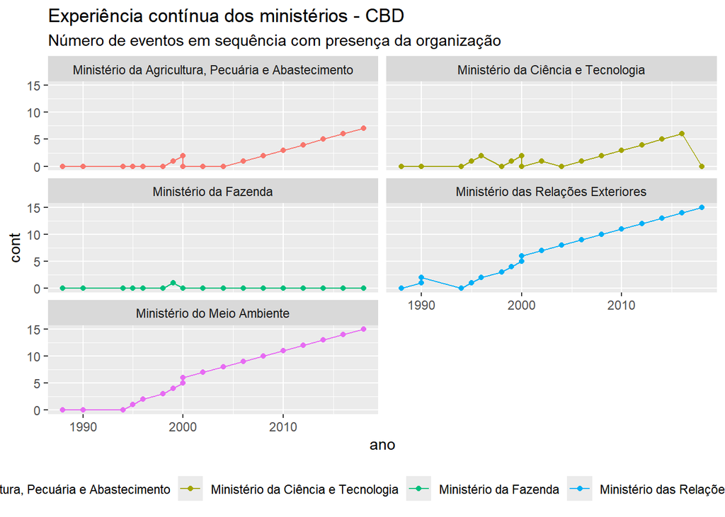

Temos abaixo os gráficos com a experiência absoluta e contínua dos indivíduos, agrupada a nível de organização. Como há múltiplos indivíduos por organização, utiliza-se a média como critério para resumir os dados. Teríamos, então, uma medida da “experiência média” dos servidores daquela organização. Como na tabela anterior, o critério de experiência é o número de eventos, não os anos de atividade (o que gera um peso algo excessivo nos primeiros anos de INCs, vide MCT em clima).

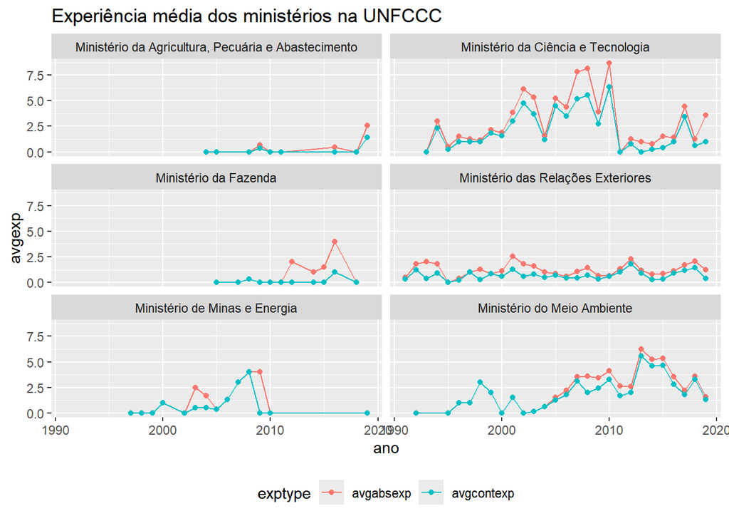

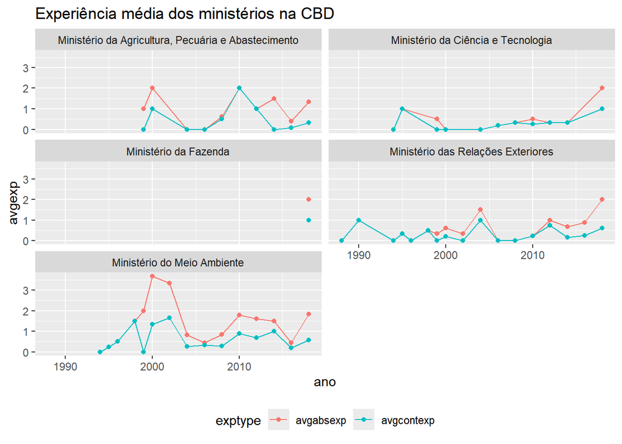

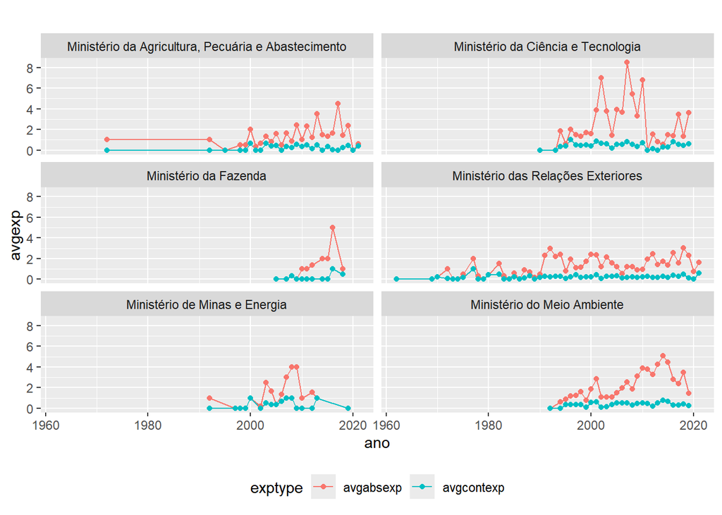

Número de indivíduos distintos presentes em algum evento da UNFCCC, por organização

| org_limpo | count |
| --- | --- |
| Ministério das Relações Exteriores | 368 |
| Sem informação | 361 |
| Ministério do Meio Ambiente | 233 |
| Ministério da Ciência e Tecnologia | 192 |
| Câmara dos Deputados | 122 |
| Universidade Federal do Rio de Janeiro | 77 |
| Estado do Amazonas | 71 |
| Estado de São Paulo | 69 |
| CEBDS - Conselho Empresarial Brasileiro para o Desenvolvimento Sustentável | 67 |
| Estado do Acre | 63 |

Número de indivíduos distintos presentes em algum evento da CBD, por organização

| org_limpo | count |
| --- | --- |
| Ministério do Meio Ambiente | 165 |
| Ministério das Relações Exteriores | 88 |
| Ministério da Agricultura, Pecuária e Abastecimento | 42 |
| CEBDS - Conselho Empresarial Brasileiro para o Desenvolvimento Sustentável | 33 |
| Ministério da Ciência e Tecnologia | 29 |
| IBAMA - Instituto Brasileiro do Meio Ambiente e dos Recursos Naturais Renováveis | 23 |
| Estado de São Paulo | 22 |
| EMBRAPA - Empresa Brasileira de Pesquisa Agropecuária | 21 |
| Ministério da Saúde | 21 |
| FUNBIO - Fundo Brasileiro para a Biodiversidade | 14 |